# TP 4

Hannes Guth

2023-03-28

```r
library(fpp2) # library that includes the data set
#library(fabletools)
library(fable) # package including the function tsibble
library(dplyr) # package including the pipe operator
library(scales) # package for axis ticks labelling
library(data.table) # package including data table
```

### The following code including comments is taken from the task and only minor parts will be edited.

### The results will be commented together at the end of the document.

# ETS model, “AAdN”

```r
Paperback = books[,1] # assign the paperback data to Paperback
times <- seq(1, dim(books)[1], 1)    # vector for time
books_df <- data.frame(books[, 1:2]) # Paperback and Hardcover as data.frame

books_tsibble <- books_df |>           # create tsibble object
  mutate(Time = times, .before=1) |>
  as_tsibble(index = Time)

model_AAdN <- books_tsibble |> # create the model
  model(
    `SES` = ETS(Paperback ~ error("A") + trend("Ad") + season("N"))
    )
```

```r
set.seed(123) # set the random seed to have always the same random numbers generation

h.step <- 10 # 10-step ahead
R <- 1000 # num of replicates

# for the bootstrap case
l.mat <- matrix(nr=h.step, nc=R)
b.mat <- matrix(nr=h.step, nc=R)
y <- matrix(nr=h.step, nc=R)

# for the normal distribution case
l.mat.norm <- matrix(nr=h.step, nc=R)
b.mat.norm <- matrix(nr=h.step, nc=R)
y.norm <- matrix(nr=h.step, nc=R)
```

```r
a <- unlist(report(model_AAdN))
```

```
## Series: Paperback
## Model: ETS(A,Ad,N)
##   Smoothing parameters:
##     alpha = 0.03259223
##     beta  = 0.0001000242
##     phi   = 0.98
##
##   Initial states:
##      l[0]     b[0]
##  171.8317 1.835088
##
##   sigma^2:  1220.294
##
##      AIC     AICc      BIC
## 321.7717 325.4239 330.1789
```

```r
# last l
l.30 <- a$SES.fit.states.l31         # 208.2084

# last b
b.30 <- a$SES.fit.states.b31         # 0.9943547

# alpha
alpha <- a$SES.fit.par.estimate1    # 0.03259223

# beta
beta <- a$SES.fit.par.estimate2     # 0.0001000242

# phi
phi <- a$SES.fit.par.estimate3      # 0.98

# sigma
sigma <- sqrt(a$SES.fit.fit.sigma2) # 34.9327
```

```r
## initialization of y_31, b_31 and l_31

set.seed(123) # for reproducibility
eps_bs = sample(components(model_AAdN)$remainder[2:31], 1000, replace = TRUE) # apply sample with replacement on the remainders of the model to generate the error terms (bootstrap)
eps_nd = rnorm(n=R, mean=0 , sd=sigma) # generate error terms through applying the normal distribution

y[1, ] <- l.30 + phi*b.30 + eps_bs # set the 31. "true" value using the bootstrap error terms
l.mat[1, ] <- l.30 + phi*b.30 + alpha*eps_bs # calculate the 31. level estimation
b.mat[1, ] <- phi*b.30 + beta*eps_bs # set the 31. b

# same for the residuals of the normal distribution
y.norm[1, ] <- l.30 + phi*b.30 + eps_nd
l.mat.norm[1, ] <- l.30 + phi*b.30 + alpha*eps_nd
b.mat.norm[1, ] <- phi*b.30 + beta*eps_nd

## the loop for the next steps
for(h in 2:10) {
  # recalculate the values as in the initialization but with the respective previous values for the bootstrap method
  eps_bs = sample(components(model_AAdN)$remainder[2:31], 1000, replace = TRUE)
  y[h,] <- l.mat[h-1,] + phi*b.mat[h-1,] + eps_bs
  l.mat[h,] <- l.mat[h-1,] + phi*b.mat[h-1,] + alpha*eps_bs
  b.mat[h,] <- phi*b.mat[h-1,] + beta*eps_bs

  # recalculate the values as in the initialization but with the respective previous values for the normal distribution method
  eps_nd = rnorm(n=R, mean=0, sd=sigma)
  y.norm[h,] <- l.mat[h-1,] + phi*b.mat[h-1,] + eps_nd
  l.mat.norm[h,] <- l.mat[h-1,] + phi*b.mat[h-1,] + alpha*eps_nd
  b.mat.norm[h,] <- phi*b.mat[h-1,] + beta*eps_nd
}
```

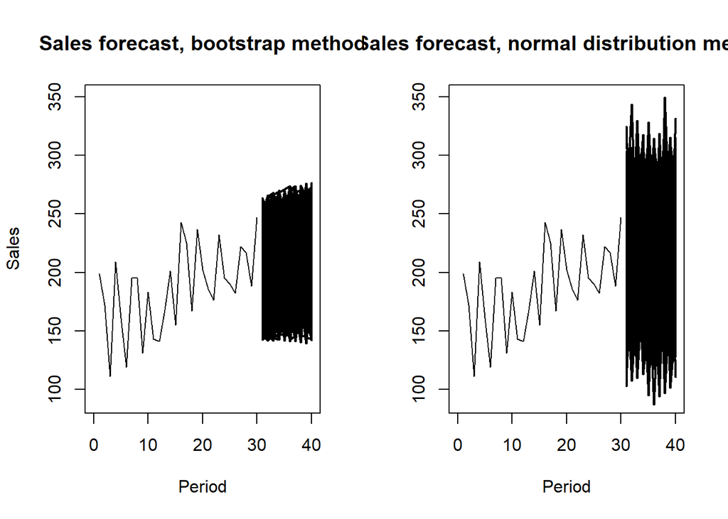

```r
par(mfrow=c(1,2)) # arrange the plots

plot(Paperback, xlim = c(0, 40), ylim = c(90, 350), main = "Sales forecast, bootstrap method", ylab = "Sales", xlab = "Period") # create at plot, showing the forecast for the bootstrap method

for(j in c(1:1000)) { # plot 1000 paths just for illustration (bootstrap method)
  points(y[,j] ~ c(31:40), type = "l", lwd = 2)
}


plot(Paperback, xlim = c(0, 40), ylim = c(90, 350), main = "Sales forecast, normal distribution method", ylab = "", xlab = "Period") # create at plot, showing the forecast for the normal distribution method

for(j in c(1:1000)) { # plot 1000 paths just for illustration (normal distribution method)
  points(y.norm[,j] ~ c(31:40), type="l", lwd=2)
}
```

## **Code of No 6:** 6. Use the simulated y to compute the following statistics:

#### a. the prediction intervals at 95% for the 10-days ahead

#### b. the distribution (histogram + summary numbers) of the total sales over the next 5-days

#### c. the probability that the sales will increase during the next 3-days.

Note: loop “for” can be used or the apply function. apply(y, 1, mean) means “apply function mean for each row of y”. apply(y, 2, sd) means “apply function sd for each column of y”.

For the upcoming exercises, there will be a comparison drawn between the approach using the normal distribution and the bootstrap method. The comments can be found below.

#### a. The prediction intervals at 95% for the 10-days ahead

Both interval lines will be plotted in the same graph for comparison.

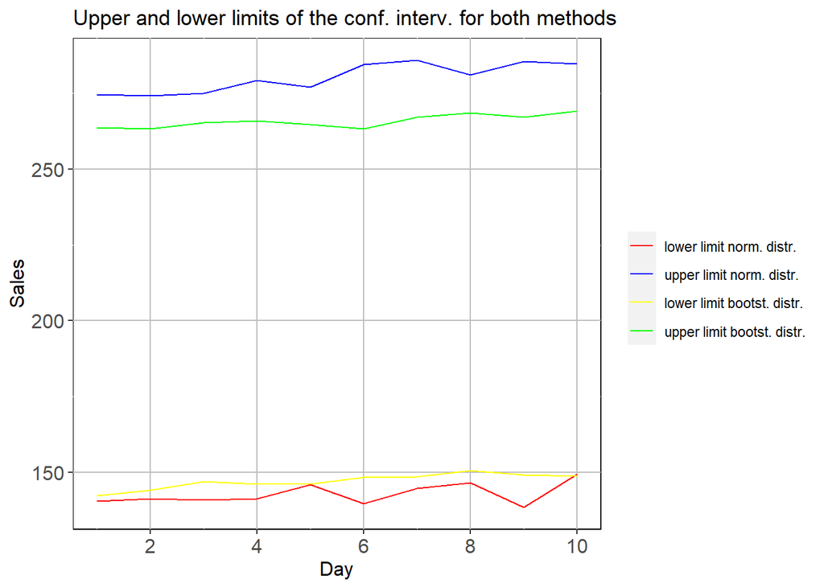

```r
# create a new data table with prediction intervals for the 10 single days
table = transpose(data.table(apply(y.norm, 1, quantile, probs=c(0.025, 0.975))))
table$V3 = transpose(data.table(apply(y, 1, quantile, probs=c(0.025, 0.975)))[1])
table$V4 = transpose(data.table(apply(y, 1, quantile, probs=c(0.025, 0.975)))[2])

ggplot(table) + # create a new ggplot with the previously created data
  geom_line(aes(y = V1, x = seq(1,10,1), color = "lower limit norm. distr.")) + # plot the data for the normal distribution, lower limit
  geom_line(aes(y = V2, x = seq(1,10,1), color = "upper limit norm. distr.")) + # as above
  geom_line(aes(y = V3, x = seq(1,10,1), color = "lower limit bootst. distr.")) + # as above
  geom_line(aes(y = V4, x = seq(1,10,1), color = "upper limit bootst. distr.")) + # as above
  scale_color_manual(values = c("lower limit norm. distr." = "red", # set the color for the normal distribution, lower limit
                                "upper limit norm. distr." = "blue", # as above
                                "lower limit bootst. distr." = "yellow", # as above
                                "upper limit bootst. distr." = "green")) + # as above
  labs(title = "Upper and lower limits of the conf. interv. for both methods", y = "Sales", x = "Day") + # edit the labels
  theme(legend.title = element_blank(), # remove the legend title
          axis.text=element_text(size=12), # change the axis text size
          axis.title=element_text(size=12), # change the axis title size
          panel.background = element_rect(fill = "white", colour = "black"), # change the background colors
          panel.grid.major = element_line(colour = "grey", size = 0.5)) + # change the grid appearance
  scale_x_continuous(breaks=pretty_breaks()) # change the scale to integers
```

#### b. The distribution (histogram + summary numbers) of the total sales over the next 5-days

```r
# show the summary statistics for both methods
y.tot.norm <- apply(y.norm[1:5, ], 2, sum)
summary(y.tot.norm)
```

```
##    Min. 1st Qu.  Median    Mean 3rd Qu.    Max.
##     822     997    1052    1051    1103    1289
```

```r
y.tot.bootstrap <- apply(y[1:5, ], 2, sum)
summary(y.tot.bootstrap)
```

```
##    Min. 1st Qu.  Median    Mean 3rd Qu.    Max.
##   810.3   983.1  1038.8  1036.2  1089.3  1247.7
```

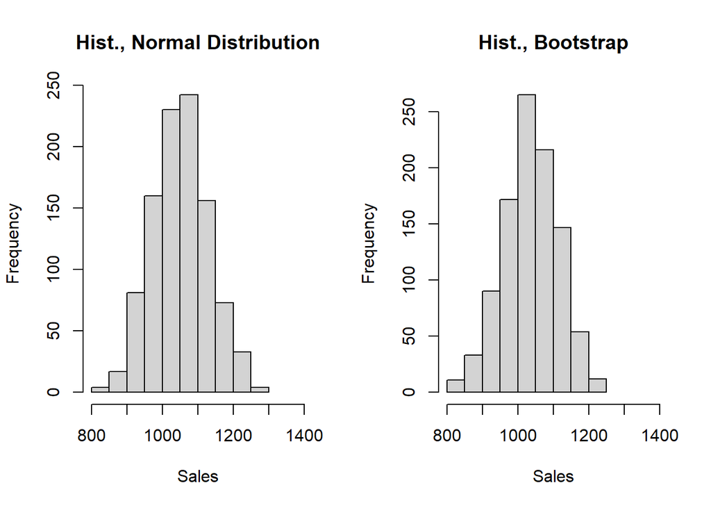

```r
# plot the distribution for the next 5 days
par(mfrow=c(1,2))
hist(y.tot.norm, xlim=range(800:1400),breaks = 9, main = "Hist., Normal Distribution", xlab = "Sales")
hist(y.tot.bootstrap, xlim=range(800:1400), breaks = 9, main = "Hist., Bootstrap", xlab = "Sales")
```

#### c. The probability that the sales will increase during the next 3-days.

```r
# calculate the probability of daily increasing sales
mean((y.norm[1,]<y.norm[2,])&(y.norm[2,]<y.norm[3,]))
```

```
## [1] 0.195
```

```r
mean((y[1,]<y[2,])&(y[2,]<y[3,]))
```

```
## [1] 0.203
```

### What does bootstrap mean taking into account the context of the exercise?

Bootstrap, in this context, means to take a random sample with replacement, in this case of the residuals/remainders the model_AAdN produces.

### Why and when can it be applied?

It is applied here because the normal distribution is possibly not a justified assumption and the bootstrap does not rely on the data being normally distributed.

### Comment on your results.

Plotting the forecast at the end of No. 5, one can easily observe a lower variance for the bootstrap method than for the normal distribution method. This is also reflected in the plot for the confidence interval of these methods. The confidence interval for the normal distribution method is constantly larger than the one for the bootstrap method.

The both distributions look approximately the same. The values retrieved from forecasting with errors from the normal distribution method shows a few more observation in the tails, as could have been expected after analyzing the previous graphs. The histogram for the bootstrap method is therefore slightly more dense in the center.

The probability for a continuous sales increase during the next 3 days is approximately 20% and with that similar for both methods. It is slightly higher for the bootstrap method with 20.3% than for the method using the normal distribution which results in 19.5%.

## References

### Packages

Hyndman R (2023). *fpp2: Data for “Forecasting: Principles and Practice” (2nd Edition)*. R package version 2.5, https://CRAN.R-project.org/package=fpp2.

O’Hara-Wild M, Hyndman R, Wang E (2022). *fable: Forecasting Models for Tidy Time Series*. R package version 0.3.2, https://CRAN.R-project.org/package=fable.

Wickham H, François R, Henry L, Müller K (2022). *dplyr: A Grammar of Data Manipulation*. R package version 1.0.10, https://CRAN.R-project.org/package=dplyr.

Wickham H, Seidel D (2022). *scales: Scale Functions for Visualization*. R package version 1.2.1, https://CRAN.R-project.org/package=scales.

Dowle M, Srinivasan A (2021). *data.table: Extension of `data.frame`*. R package version 1.14.2, https://CRAN.R-project.org/package=data.table.